# clustcurv: An R Package for Determining Groups in Multiple Curves

### 4.2 Application to Multiple Myeloma Study Data

In this case, a study of the survival in patients with multiple myeloma (MM) cancer was conducted. 256 individuals were included from the start of the follow-up to whom were analyzed and collected 16 variables. This data set is freely available in the *survminer* package. Below, it is shown the first rows of the `data.frame` with columns such as treatment (`treatment`), life state indicator (`event`; censored – 0; 1 – dead), survival time (`time`, in months), among others.

```r
> library(survminer)
> data(myeloma)
> head(myeloma[,1:5])
         molecular_group chr1q21_status treatment event  time
GSM50986      Cyclin D-1       3 copies       TT2     0 69.24
GSM50988      Cyclin D-2       2 copies       TT2     0 66.43
GSM50989           MMSET       2 copies       TT2     0 66.50
GSM50990           MMSET       3 copies       TT2     1 42.67
GSM50991             MAF           <NA>       TT2     0 65.00
GSM50992    Hyperdiploid       2 copies       TT2     0 65.20
```

In this example, it is interesting to analyze if the survival in patients with MM disease is the same for the different molecular subgroups. If there is an effect of the molecular subgroups on the survival, future therapies that might exploit molecular insights should lead to an improvement in outcome for patients with these types of disease (Zhan et al. 2006).

Below, a summary of the results of the `survclustcurves` function obtained with `time`, `event`, and `molecular_group` as input variables and for both `kmedians` and `kmeans` algorithms are shown.

```r
> fit.mye <- survclustcurves(time = myeloma$time, status = myeloma$event,
                      x = myeloma$molecular_group, nboot = 500, seed = 300716,
                      algorithm = 'kmedians', cluster = TRUE)
Checking 1 cluster...
Checking 2 clusters...

Finally, there are 2 clusters.
> summary(fit.mye)

Call:
survclustcurves(time = myeloma$time, status = myeloma$event,
    x = myeloma$molecular_group, nboot = 500, algorithm = "kmedians",
    cluster = TRUE, seed = 300716)

Clustering curves in 2 groups

Number of observations:  248
Cluster method:  kmedians

Factor's levels:
[1] "Cyclin D-1"       "Cyclin D-2"       "Hyperdiploid"     "Low bone disease"
[5] "MAF"              "MMSET"            "Proliferation"

Clustering factor's levels:
[1] 1 1 1 1 1 2 2

Testing procedure:
  H0   Tvalue pvalue
1  1 31.31603  0.026
2  2 14.94269  0.682

Available components:
 [1] "num_groups" "table"      "levels"     "cluster"    "centers"    "curves"
 [7] "method"     "data"       "algorithm"  "call"

> fit.mye2 <- survclustcurves(time = myeloma$time, status = myeloma$event,
                      x = myeloma$molecular_group, nboot = 500, seed = 300716,
                      algorithm = 'kmeans', cluster = TRUE)
Checking 1 cluster...
Checking 2 clusters...

Finally, there are 2 clusters.





> summary(fit.mye2)

Call:
survclustcurves(time = myeloma$time, status = myeloma$event,
    x = myeloma$molecular_group, nboot = 500, algorithm = "kmeans",
    cluster = TRUE, seed = 300716)

Clustering curves in 2 groups

Number of observations:  248
Cluster method:  kmeans

Factor's levels:
[1] "Cyclin D-1"       "Cyclin D-2"       "Hyperdiploid"     "Low bone disease"
[5] "MAF"              "MMSET"            "Proliferation"

Clustering factor's levels:
[1] 1 1 1 1 1 2 2

Testing procedure:
  H0   Tvalue pvalue
1  1 4.500272  0.032
2  2 1.108812  0.730

Available components:
 [1] "num_groups" "table"      "levels"     "cluster"    "centers"    "curves"
 [7] "method"     "data"       "algorithm"  "call"
```

When comparing the results obtained through the two methods (`kmeans`, `kmedians`), it is seen that the obtained number of clusters is the same (2 groups), even the assignment of the curves to the groups.

In particular, results obtained reveal that MMSET level and Proliferation level are associated with a high-risk or damage on the lifetime, while MAF, Low bone disease, Hyperdiploid, Cycline D-1, and Cycline D-2 have higher survival probabilities. This is observed in the plot shown in Figure 3, which can be obtained using the following input command:

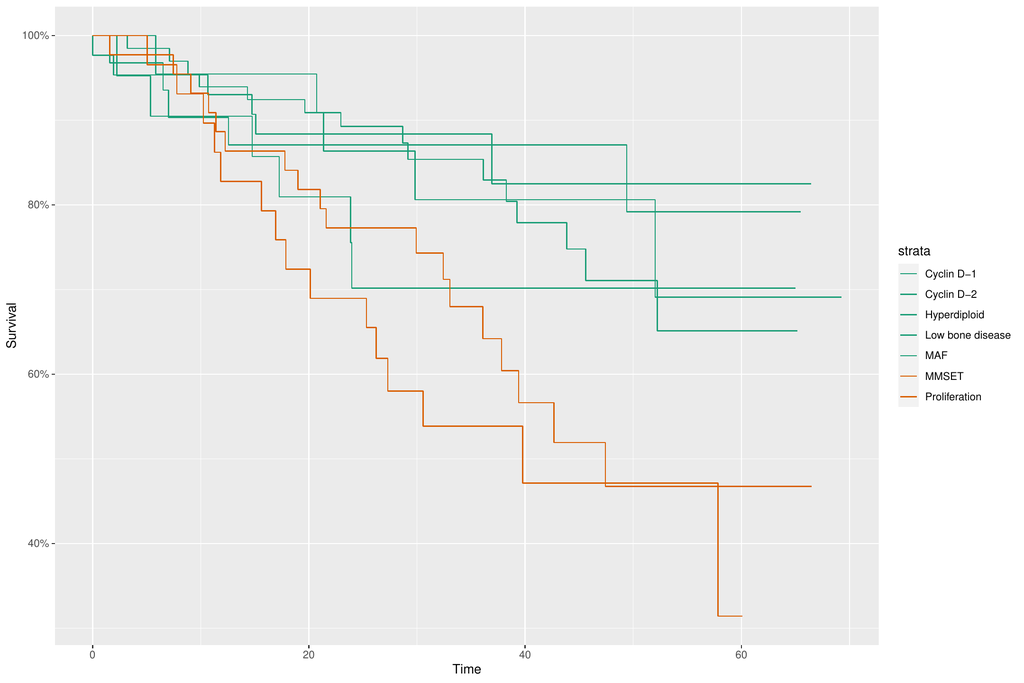

Figure 3: Estimated survival curves for each of the levels of the variable `molecular group`. A specific color is assigned for each curve according to the group to which it belongs using the $K$-medians algorithm, two groups, $K$ = 2.

```r
> autoplot(fit.mye, groups_by_color = TRUE)
```

### 4.3 Application to Barnacle’s Growth Study Data

This study was conducted on the Atlantic coast of Galicia (Northwest Spain), which consists of an approximately 1000km long shoreline with extensive rocky stretches exposed to tidal surges and wave action that are settled by the *Pollicipes pollicipes* (Gmelin, 1789) populations targeted for study. A total of 5000 specimens were collected from five sites of the region’s Atlantic coastline and corresponded to the stretches of coast where this species is harvested: Punta do Mouro, Punta Lens, Punta de la Barca, Punta del Boy and Punta del Alba. Two biometric variables of each specimen were measured: RC (Rostro-carinal length, maximum distance across the capitulum between the ends of the rostral and carinal plates) and DW (Dry Weight). This data set (`barnacle5`) is available in the *clustcurv* package. The idea of this study is to know the relation between RC and DW variables along the coast, i.e., to analyze if the barnacle’s growth is similar in all locations or by contrast, if it is possible to detect geographical differentiation in growth. A sample of the dataset is shown as follow:

```r
> data("barnacle5")
> head(barnacle5)
    DW   RC    F
1 0.52 12.0 laxe
2 1.46 18.9 laxe
3 0.05  6.4 laxe
4 0.17  9.4 laxe
5 0.05  6.2 laxe
6 0.41 12.2 laxe
```

```r
> fit.bar <- regclustcurves(y = barnacle5$DW, x = barnacle5$RC, z = barnacle5$F,
               nboot = 500, seed = 300716, algorithm = 'kmeans', cluster = TRUE)

Checking 1 cluster...
Checking 2 clusters...
Checking 3 clusters...

Finally, there are 3 clusters.

> summary(fit.bar)

Call:
regclustcurves(y = barnacle5$DW, x = barnacle5$RC, z = barnacle5$F,
    nboot = 500, algorithm = "kmeans", cluster = TRUE, seed = 300716)

Clustering curves in 3 groups

Number of observations:  5000
Cluster method:  kmeans

Factor's levels:
[1] "laxe"  "lens"  "barca" "boy"   "alba"

Clustering factor's levels:
[1] 2 1 3 3 2


Testing procedure:
  H0     Tvalue pvalue
1  1 0.94353014  0.000
2  2 0.15463483  0.034
3  3 0.02348982  0.422

Available components:
 [1] "num_groups" "table"      "levels"     "cluster"    "centers"    "curves"
 [7] "method"     "data"       "algorithm"  "call"
```

As can be seen, Figure 4 obtained using the following input command. The specimens from Punta de la Barca and Punta del Boy have similar morphology, wide and short. This is due to these zones present similar oceanographic characteristic, such as exposed rocky shore to waves and highly articulated. Unlike, the barnacles collected from Laxe do Moure and Punta del Alba are narrow and long because they are less exposed locations. Finally, Punta Lens is an intermediate coast, alternating sections of steep coast with large sand.

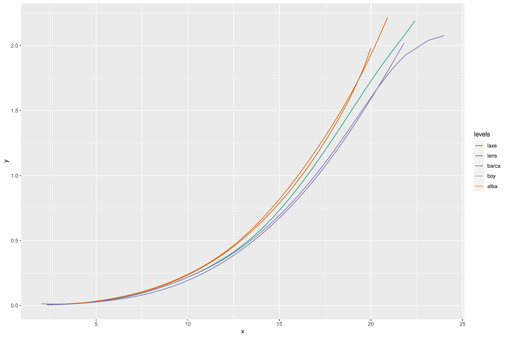

Figure 4: Estimated regression curves for each of the levels of the factor. A specific color is assigned for each curve according to the group to which it belongs using the $K$-means algorithm (in this case, three groups, $K$ = 3).

```r
> autoplot(fit.bar, groups_by_color = TRUE)
```

### 4.4 Application to simulated data

Finally, this subsection reports the capabilities of the *clustcurv* package in a more complicated simulated scenario. We consider the regression models given in ((1)) for $j=1, \ldots, 30$, with

$$\label{noramv:eq2}
m_j(X_j)=\left \{ {
\begin{array}{lcc}
X_j + 1 {\text if} \quad j \le 5 \\
X_j^2 + 1 {\text if} \quad 5 < j \le 10 \\
2 {\rm sin} (2 X_j) {\text if} \quad 10 < j \le 15 \\
2 {\rm sin}(X_j) {\text if} \quad 15 < j \le 20 \\
2 {\rm sin} (X_j) + a \mathrm{e}^{X_j} {\text if} \quad 20 < j \le 25 \\
1 {\text if} \quad j > 25 ,\\
\end{array}
}\right. \tag{3}$$

where $a$ is a real constant, $X_j$ is the explanatory covariate drawn from a uniform distribution $[-2,2]$, and $\varepsilon_j$ is the error distributed in accordance to a $N(0, \sigma_j(x))$. We have considered the heteroscedastic scenario where $\sigma_j(x)=0.5+0.05m_j(x) \cdot N(0, 1.5)$.

We explore the methodology considering the null hypothesis $H_0(5)$ of assignment of the $m_j$ curves into five groups ($K= 5$). To show the performance of our procedure, two values were considered for $a$, 0 and 0.4. It should be noted that the value $a=0$ corresponds to the null hypothesis, while if $a=0.4$ the number of groups is six. Particularly, we have defined an unbalanced scenario with unequal sample sizes for each $j$ curve, particularly, $(n_1, n_2, \ldots, n_J) \sim$ Multinomial$(n; p_1, p_2, \ldots, p_J)$ being $p_j = p_j^\ast /\sum_{j=1}^{J} p_j^\ast$, with $p_j^\ast$ randomly drawn from $\{1, 1.5, 2, 2.5, 3\}$ and $n = 5000$. Note that we propose this procedure for generating the $n_j$ in order to obtain a completely unbalanced study.

The code for the generation of this dataset with $a=0$ can be found below:

```r
> m <- function(x, j) {
   y <- numeric(length(x))
   y[j <= 5] <- x[j <= 5] + 1
   y[j > 5 & j <= 10] <- x[j > 5 & j <= 10] ^ 2 + 1
   y[j > 10 & j <= 15] <- 2 * sin(2 * x[j > 10 & j <= 15]) #- 4
   y[j > 15 & j <= 20] <- 2 * sin(x[j > 15 & j <= 20])
   y[j > 20 & j <= 25] <- 2 * sin(x[j > 20 & j <= 25]) + a * exp(x[j > 20 & j <= 25])
   y[j > 25] <- 1
   return(y)
 }

> seed <- 300716
> set.seed(seed)
> n <- 5000
> a <- 0.0
> x <- runif(n, -2, 2)
> prob <- sample(c(1, 1.5, 2, 2.5, 3), 30, replace = TRUE)
> prob <- prob/sum(prob)
> f <- sample(1:30, n, replace = TRUE, prob = prob)
> N <- length(unique(f))
> error <- rnorm(n,0,1.5)
> y <- m(x, f) + (0.5 + 0.05 * m(x, f)) * error
> data <- data.frame(x, y, f)
```

In order to determine groups of the generated curves, the user has to execute the next piece of code. As expected, when $a=0$, the number of groups selected is five.

```r
> fit.sim <- regclustcurves(x = data$x, y = data$y,  z = data$f, nboot = 500,
                     algorithm = 'kmedians', cluster = TRUE, seed = 300716)
Checking 1 cluster...
Checking 2 clusters...
Checking 3 clusters...
Checking 4 clusters...
Checking 5 clusters...

Finally, there are 5 clusters.
> fit.sim

Call:
regclustcurves(y = data$y, x = data$x, z = data$f, nboot = 500,
    algorithm = "kmedians", cluster = TRUE, seed = 300716)

Clustering curves in 5 groups

Number of observations:  5000
Cluster method:  kmedians
> autoplot(fit.sim, groups_by_colour = TRUE, centers = TRUE)
```

Additionally, for different values of $a$ (a > 0), our procedure should determine 6 groups. For instance, for $a = 0.4$, it selects the true number of groups ($K=6$) typing the commands below:

```r
> seed <- 300716
> set.seed(seed)
> n <- 5000
> a <- 0.4
> x <- runif(n, -2, 2)
> prob <- sample(c(1, 1.5, 2, 2.5, 3), 30, replace = TRUE)
> prob <- prob/sum(prob)
> f <- sample(1:30, n, replace = TRUE, prob = prob)
> N <- length(unique(f))
> error <- rnorm(n,0,1.5)
> y <- m(x, f) + (0.5 + 0.05 * m(x, f)) * error
> data2 <- data.frame(x, y, f)
> fit.sim2 <- regclustcurves(x = data2$x, y = data2$y,  nboot = 500, seed = 300716,
                         z = data$f, algorithm = 'kmedians', cluster = TRUE)
Checking 1 cluster...
Checking 2 clusters...
Checking 3 clusters...
Checking 4 clusters...
Checking 5 clusters...
Checking 6 clusters...

Finally, there are 6 clusters.
> fit.sim2

Call:
regclustcurves(y = data2$y, x = data2$x, z = data$f, nboot = 500,
    algorithm = "kmedians", cluster = TRUE, seed = 300716)

Clustering curves in 6 groups

Number of observations:  5000
Cluster method:  kmedians
> autoplot(fit.sim2, groups_by_colour = TRUE, centers = TRUE)
```

Figures 5 and 6 show the results with the simulated data with $a=0$ and $a=0.4$, respectively. In this situation, the true number of groups is equal to 5 and 6. As can be appreciated, our method seems to perform reasonably well for both values of $a$. For $a=0$, the null hypothesis $H_0(5)$ is accepted, curves assigned to each group are plotted with the same color. In the case of $a=0.4$, the null hypothesis $H_0(6)$ is accepted. Therefore, there are 6 groups of regression curves. Note that in both plots, the centroids are colored in black because in the `autoplot` function, the argument `centers = TRUE`.

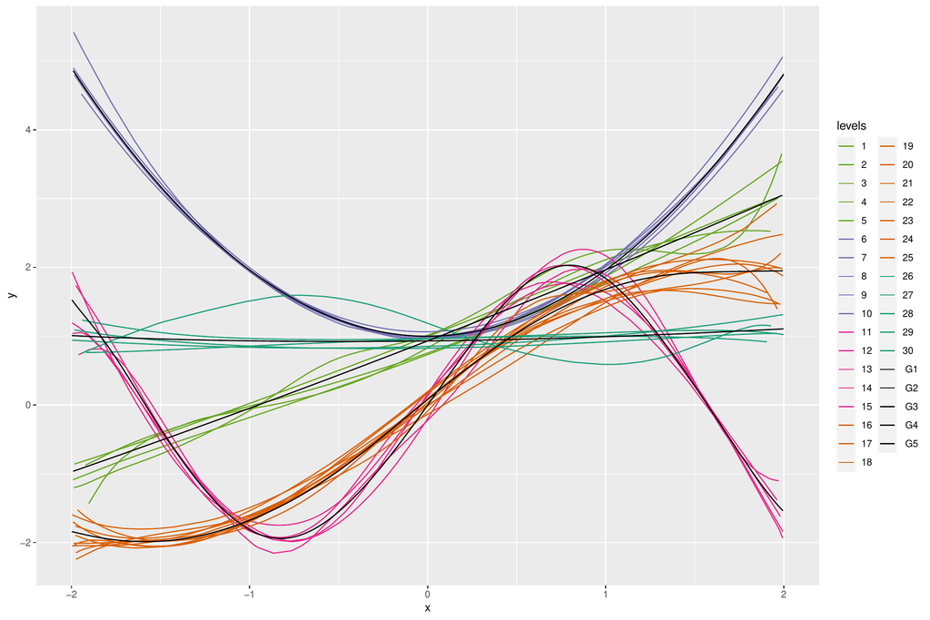

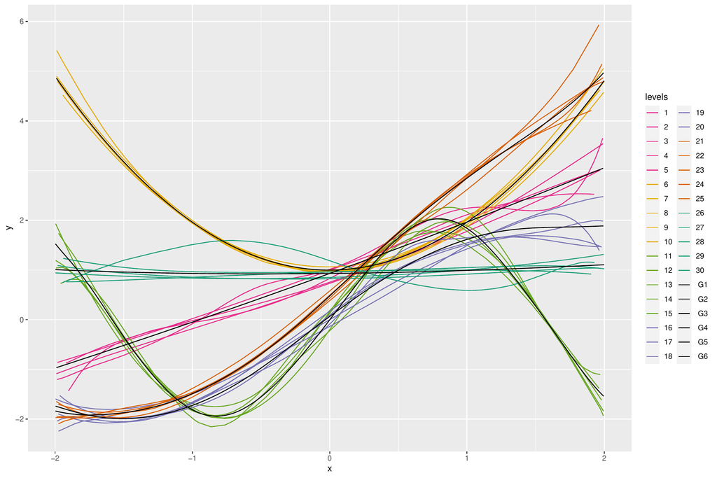

## Conclusion and further extensions of the R package

This paper discussed the implementation of some methods developed for determining groups of multiple nonparametric curves in the R package *clustcurv*. In particular, the methods proposed are focused on the framework of regression analysis and in the framework of survival analysis. In the context of survival analysis, we restrict ourselves to survival curves. Hopefully, future versions of the package will extend the methodology to determine groups in risk functions, cumulative hazard curves, or density functions. The current version of the package implements two optimization algorithms, the well-known $K$-means and $K$-medians. It can be interesting to let the user choose far from those, such as Means-Shift or $K$-medoids algorithms.

## Acknowledgements

The authors acknowledge financial support by the Spanish Ministry of Economy and Competitiveness (MINECO) through project MTM2017-89422-P and MTM2017-82379-R (funded by (AEI/FEDER, UE). Thanks to the Associate Editor and the referee for comments and suggestions that have improved this paper.

### 4.5 Supplementary materials

Supplementary materials are available in addition to this article. It can be downloaded at RJ-2021-032.zip

### 4.6 CRAN packages used

clustcurv, survminer, npregfast, ggplot2, doParallel, foreach, condSURV

### 4.7 CRAN Task Views implied by cited packages

ChemPhys, HighPerformanceComputing, NetworkAnalysis, Phylogenetics, Spatial, Survival, TeachingStatistics

C. A. de Boor. *A practical guide to splines.* New York: Springer Verlag, 2001.

Z. Chen and G. Zhang. Comparing survival curves based on medians. *BMC Medical Research Methodology*, 16(1): 33, 2016. URL http://dx.doi.org/10.1186/s12874-016-0133-3.

M. A. Delgado. Testing the equality of nonparametric regression curves. *Statistics and Probability Letters*, 17: 199–204, 1993.

D. Dette and N. Neumeyer. Nonparametric analysis of covariance. *The Annals of Statistics*, 29: 1361–1400, 2001.

S. Dudoit and M. J. van der Laan. *Multiple testing procedures with applications to genomics.* New York: Springer, 2008.

B. Efron. Bootstrap methods: another look at the jackknife. *The Annals of Statistics*, 7: 1–26, 1979.

J. Fan and I. Gijbels. *Local polynomial modelling and its applications.* Chapman & Hall, 1996.

T. R. Fleming, D. P. Harrington and M. O’Sullivan. Supremum versions of the log-rank and generalized wilcoxon statistics. *Journal of the American Statistical Association*, 82(397): 312–320, 1987. URL http://www.jstor.org/stable/2289169.

E. A. Gehan. A generalized wilcoxon test for comparing arbitrarily singly censored samples. *Biometrika*, 52: 203–223, 1965. URL http://www.jstor.org/stable/2333825.

W. González-Manteiga and R. Cao. Testing the hypothesis of a general linear model using nonparametric regression estimation. *Test*, 2(1): 223–249, 1993.

P. Hall and J. D. Hart. Bootstrap test for difference between means in nonparametric regression. *Journal of the American Statistical Association*, 85(412): 1039–1049, 1990.

W. Härdle and E. Mammen. Testing parametric versus nonparametric regression. *Annals of Statistics*, 21: 1926–1947, 1993.

D. P. Harrington and T. R. Fleming. A class of rank test procedures for censored survival data. *Biometrika*, 69(3): 553, 1982. URL + http://dx.doi.org/10.1093/biomet/69.3.553.

S. Holm. A simple sequentially rejective multiple test procedure. *Scandinavian Journal of Statistics*, 6: 65–70, 1979.

E. L. Kaplan and P. Meier. Nonparametric estimation from incomplete observations. *Journal of the American Statistical Association*, 53: 457–481, 1958.

A. Kassambara, M. Kosinski, P. Biecek and S. Fabian. survminer: Drawing Survival Curves using ’ggplot2’. 2019. URL https://cran.r-project.org/web/packages/survminer.

L. Kaufman and P. J. Rousseeuw. *Finding groups in data: An introduction to cluster analysis.* John Wiley, 1990.

E. King, J. D. Hart and T. E. Wehrly. Testing the equality of two regression curves using linear smoothers. *Statistics and Probability Letters*, 12(3): 239–247, 1991.

K. B. Kulasekera. Comparison of regression curves using quasi-residuals. *Journal of the American Statistical Association*, 90(431): 1085–1093, 1995.

S. Lang and A. Brezger. Bayesian p-splines. *Journal of Computational and Graphical Statistics*, 13: 183–212, 2004.

R. Y. Liu. Bootstrap Procedures under some Non-I.I.D. Models. *The Annals of Statistics*, 16(4): 1696–1708, 1988. URL http://www.jstor.org/stable/2241788.

J. B. Macqueen. *Some methods of classification and analysis of multivariate observations.* Proceedings of the Fifth Berkeley Symposium on Mathematical Statistics; Probability (Univ. of Calif. Press), 1967.

E. Mammen. Bootstrap and Wild Bootstrap for High Dimensional Linear Models. *The Annals of Statistics*, 21(1): 255–285, 1993. URL http://www.jstor.org/stable/3035590.

N. Mantel. Evaluation of survival data and two new rank order statistics arising in its consideration. *Cancer Chemotherapy Reports*, 50(3): 163–170, 1966.

N. Neumeyer and H. Dette. Nonparametric comparison of regression curves: An empirical process approach. *The Annals of Statistics*, 31(3): 880–920, 2003.

J. C. Pardo-Fernández, I. Van Keilegom and W. González-Manteiga. Testing for the equality of k regression curves. *Statistica Sinica*, 17: 1115–1137, 2007.

R. Peto and J. Peto. Asymptotically efficient rank invariant test procedures (with discussion). *Journal of the Royal Statistical Society, Series A*, 135: 185–206, 1972.

M. Rosenblatt. A quadratic measure of deviation of two-dimensional density estimates and a test of independence. *The Annals of Statistics*, 3(1): 1–14, 1975.

R. Srihera and W. Stute. Nonparametric comparison of regression functions. *Journal of Multivariate Analysis*, 101: 2039–2059, 2010.

R. E. Tarone and J. Ware. On distribution-free tests for equality of survival distribution. *Biometrika*, 64: 156–160, 1977.

N. M. Villanueva, M. Sestelo and L. Meira-Machado. A Method for Determining Groups in Multiple Survival Curves. *Statistics in Medicine*, 38: 366–377, 2019a.

N. M. Villanueva, M. Sestelo, C. Ordoñez and J. Roca-Pardiñas. An Approach to Determine Groups of Multiple Regression Curves. 2019b.

M. P. Wand and M. C. Jones. *Kernel Smoothing.* Chapman & Hall: London, 1995.

H. Wickham, W. Chang, L. Henry, T. L. Pedersen, K. Takahashi, C. Wilke, K. Woo and H. Yutani. ggplot2: Create Elegant Data Visualisations Using the Grammar of Graphics. 2019. URL https://cran.r-project.org/web/packages/ggplot2.

C. F. J. Wu. Jackknife, Bootstrap and other resampling methods in regression analysis. *The Annals of Statistics*, 14(4): 1261–1295, 1986. URL http://dx.doi.org/10.2307/2241454.

S. G. Young and A. W. Bowman. Nonparametric analysis of covariance. *Biometrics*, 51: 920–931, 1995.

F. Zhan, Y. Huang, S. Colla, J. P. Stewart, I. Hanamura, S. Gupta, J. Epstein, S. Yaccoby, J. Sawyer, B. Burington, et al. The molecular classification of multiple myeloma. *Blood*, 108(6): 2020–2028, 2006. DOI 10.1182/blood-2005-11-013458.